# practical machine learning - course project

Ly Nguyen

9/13/2020

# Summary

This project uses the pmltraining data set to predict the manner that the subjets exercise, which is defined by the variable “classe” in the training set. I will apply different prediction models that we have learnt throughout the course and applied the one with the highest level of accuracy to the test set to predict the manner of exercise.

# Data Loading and Cleaning

```r
pmltraining <- read.csv("pml-training.csv", sep=",", header=TRUE)
pmltesting <- read.csv(file="pml-testing.csv", sep=",", header=TRUE)
```

Let’s take a look at the training data set

```r
head(pmltraining)
```

```
##   X user_name raw_timestamp_part_1 raw_timestamp_part_2   cvtd_timestamp
## 1 1  carlitos           1323084231               788290 05/12/2011 11:23
## 2 2  carlitos           1323084231               808298 05/12/2011 11:23
## 3 3  carlitos           1323084231               820366 05/12/2011 11:23
## 4 4  carlitos           1323084232               120339 05/12/2011 11:23
## 5 5  carlitos           1323084232               196328 05/12/2011 11:23
## 6 6  carlitos           1323084232               304277 05/12/2011 11:23
##   new_window num_window roll_belt pitch_belt yaw_belt total_accel_belt
## 1         no         11      1.41       8.07    -94.4                3
## 2         no         11      1.41       8.07    -94.4                3
## 3         no         11      1.42       8.07    -94.4                3
## 4         no         12      1.48       8.05    -94.4                3
## 5         no         12      1.48       8.07    -94.4                3
## 6         no         12      1.45       8.06    -94.4                3
##   kurtosis_roll_belt kurtosis_picth_belt kurtosis_yaw_belt skewness_roll_belt
```

[output cut: 251 more lines]

We can see that there are a few variables with NA values and #DIV/0! values, which are not very helpful when we build our model. We also see that the first 7 columns do not contain predictor variables but identifier and timestamp variables, we can also remove them from our cleaned dataset.

```r
# Remove all columns with NA values
pmltraining <- pmltraining[ ,colSums(is.na(pmltraining))==0]

# Remove columns with "#DIV/0!" values
cols <- colSums(mapply("==", "#DIV/0!", pmltraining))
pmltraining <- pmltraining[ ,which(cols == 0)]

# Remove the first 7 columns
pmltraining <- pmltraining[, -c(1:7)]
```

Let’s take a look at our cleaned training dataset

```r
head(pmltraining)
```

```
##   roll_belt pitch_belt yaw_belt total_accel_belt gyros_belt_x gyros_belt_y
## 1      1.41       8.07    -94.4                3         0.00         0.00
## 2      1.41       8.07    -94.4                3         0.02         0.00
## 3      1.42       8.07    -94.4                3         0.00         0.00
## 4      1.48       8.05    -94.4                3         0.02         0.00
## 5      1.48       8.07    -94.4                3         0.02         0.02
## 6      1.45       8.06    -94.4                3         0.02         0.00
##   gyros_belt_z accel_belt_x accel_belt_y accel_belt_z magnet_belt_x
## 1        -0.02          -21            4           22            -3
## 2        -0.02          -22            4           22            -7
## 3        -0.02          -20            5           23            -2
## 4        -0.03          -22            3           21            -6
## 5        -0.02          -21            2           24            -6
## 6        -0.02          -21            4           21             0
##   magnet_belt_y magnet_belt_z roll_arm pitch_arm yaw_arm total_accel_arm
```

[output cut: 62 more lines]

```r
dim(pmltraining)
```

```
## [1] 19622    53
```

There are now 53 variables and 19,622 observations.

We will do the same with the testing set

```r
choose <- names(pmltesting) %in% names(pmltraining)
pmltesting <- pmltesting[choose]
dim(pmltesting)
```

```
## [1] 20 52
```

Our testing data set has **52** variables *(without the outcome: classe)* and 20 observations.

Divide training dataset into training set and validation set. For ease of running the models, my cutoff percentage is **70% train, 30% validation**.

```r
library(caret)
partition <- createDataPartition(pmltraining$classe, p=0.7, list=FALSE)
train <- pmltraining[partition, ]
val <- pmltraining[-partition, ]
dim(train)
```

```
## [1] 13737    53
```

```r
dim(val)
```

```
## [1] 5885   53
```

## Tree Classification Model

We have multiple variables that can be used to predict the outcome classe, so first, i will fit a Tree Classification Model into the train data.

```r
fitTrees <- train(classe~., method="rpart", data=train)
```

Let’s plot the Tree graph to see how the groups are classified.

```r
library(rattle)
```

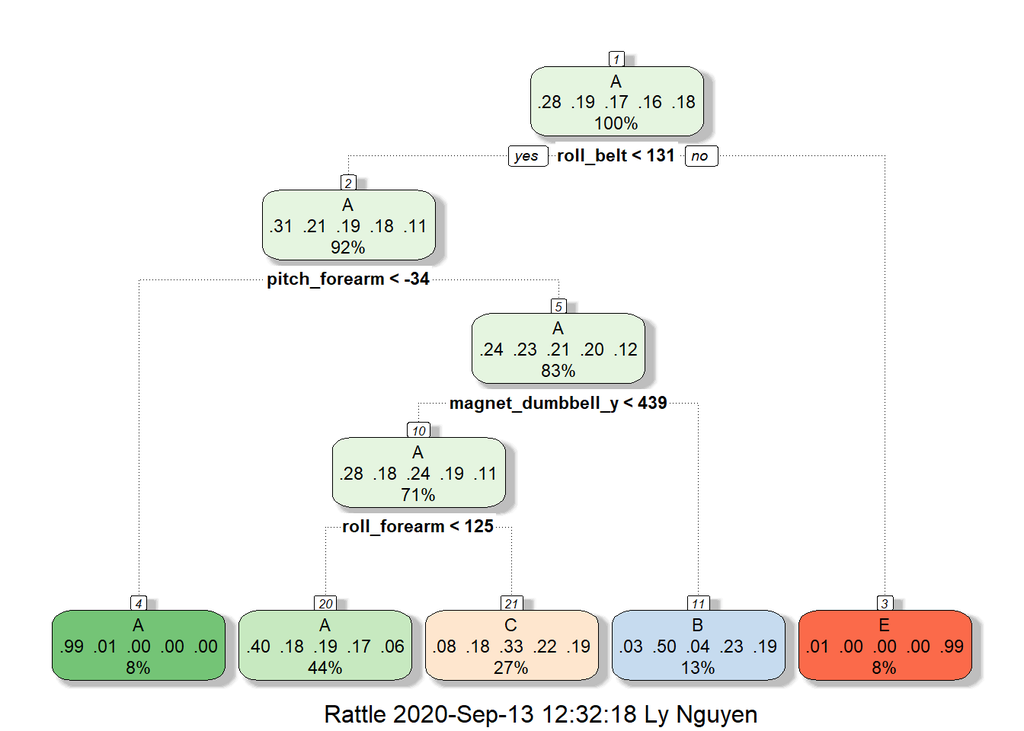

```r
fancyRpartPlot(fitTrees$finalModel)
```

Let’s validate the model on the validation data to find out how well it performs.

```r
predTrees <- predict(fitTrees, val)
accuracyTrees <- confusionMatrix(predict(fitTrees, val), factor(val$classe))$overall[[1]]
accuracyTrees
```

```
## [1] 0.5002549
```

The accuracy rate is **0.5002549** , hence the out-of-sample error is **0.4997451**, which is quite high. We may want to apply another model.

## Random Forest Model

Because we have both continuous and discrete variables, I will fit a Random Forest Model to our training data.

```r
fitRF <- train(classe~., method="rf", data=train,
               trControl = trainControl(method = 'cv', number = 5), na.action = na.omit)
```

Let’s validate the performance of this model on the validation set.

```r
predRF <- predict(fitRF, val)
accuracyRF <- confusionMatrix(predict(fitRF, val), factor(val$classe))$overall[[1]]
accuracyRF
```

```
## [1] 0.9940527
```

The accuracy rate is **0.9940527**, hence the out-of-sample error is **0.0059473**, which is very low. Although this may be due to overfitting, the model definitely performs better than the Tree Classification Model.

Below is the 20 most important variables as predictors of classe.

```r
varImp(fitRF)
```

```
## rf variable importance
##
##   only 20 most important variables shown (out of 52)
##
##                   Overall
## roll_belt          100.00
## yaw_belt            81.37
## magnet_dumbbell_z   66.84
## pitch_belt          61.49
## magnet_dumbbell_y   60.68
## pitch_forearm       60.51
## magnet_dumbbell_x   53.79
## roll_forearm        51.67
## magnet_belt_y       45.85
## accel_belt_z        44.02
## accel_dumbbell_y    43.95
## roll_dumbbell       40.03
## magnet_belt_z       38.50
## accel_dumbbell_z    36.35
## roll_arm            35.43
## accel_forearm_x     32.43
## gyros_belt_z        30.10
## yaw_dumbbell        29.55
## accel_dumbbell_x    28.73
## gyros_dumbbell_y    27.40
```

## Generalized Boosted Model

Because we have multiple weak predictors in our dataset, I will also try fitting a generalized boosted model to weigh them, add them up and derive an overall stronger predictor.

```r
fitGBM <- train(classe~., method="gbm", data=train, verbose = FALSE)
```

Let’s validate the performance of this model on the validation set.

```r
predGBM <- predict(fitGBM, val)
accuracyGBM <- confusionMatrix(predict(fitGBM, val), factor(val$classe))$overall[[1]]
accuracyGBM
```

```
## [1] 0.9658454
```

The accuracy rate is **0.9658454**, hence the out-of-sample error is **0.0341546**, which is quite low but still higher than the Random Forest Model. Hence, we will choose the **Random Forest Model** to predict on our test data set.

## Predict on Test Set

```r
predTest <- predict(fitRF,pmltesting)
predTest
```

```
##  [1] B A B A A E D B A A B C B A E E A B B B
## Levels: A B C D E
```

The predicted result will be used in the **Course Project Prediction Quiz**

## Conclusion

- After fitting 3 models on the training data set and use validation data set to evaluate their performance, I decide to choose the Random Forest Model to predict the classe value on the test data set.